# Indicator Exploratory Analysis: Doctor Visits: Smoothed Adj CLI

Author

Delphi Group

Published

August 14, 2026

This notebook evaluates a **candidate indicator** to understand its characteristics, coverage, missingness, and versioning/revision behavior.

## 1 Data Loading

```r
# Load candidate indicator. `load_note` records where the data came from and
# `n_dropped` how many rows were discarded, both reported in the prose below.
candidate_archive <- NULL
load_note <- "the source"
n_dropped <- 0L
if (!is.null(params$input_csv)) {
    # geo_value stays character: a numeric guess would strip the leading zero
    # from county FIPS codes in states 01-09 (AL, AK, AZ, AR, CA, CO, CT).
    df_candidate_raw <- read.csv(params$input_csv, colClasses = c(geo_value = "character")) %>%
        mutate(time_value = as.Date(time_value)) %>%
        filter(time_value >= as.Date(params$start_day) & time_value <= as.Date(params$end_day))

    # A file may hold more indicators than were asked for. Keep only the
    # requested ones, or every one of them would be analysed and labelled NA.
    if ("signal" %in% colnames(df_candidate_raw) && length(signals_vec) > 0) {
        df_candidate_raw <- df_candidate_raw %>% filter(signal %in% signals_vec)
    }

    # CSV may include version/issue columns for revision analysis
    has_versions <- any(c("version", "issue") %in% colnames(df_candidate_raw))
    if (has_versions) {
        df_candidate_raw <- df_candidate_raw %>%
            {
                if ("issue" %in% names(.)) rename(., version = issue) else .
            } %>%
            mutate(version = as.Date(version))

        # A row with no version has no place on a version timeline. A file
        # holding both versioned and unversioned copies of the same observations
        # is usually a build accident, and keeping both doubles every series.
        n_dropped <- sum(is.na(df_candidate_raw$version))
        if (n_dropped > 0) df_candidate_raw <- df_candidate_raw %>% filter(!is.na(version))

        # Confidence bounds ride along as extra value columns, so the overview
        # plot can draw bands for versioned CSVs too.
        csv_archive_df  <- df_candidate_raw %>%
            select(geo_value, time_value, version, any_of("signal"), any_of(params$extra_keys),
                   value, any_of(c("ci_lower", "ci_upper"))) %>%
            group_by(geo_value, time_value, version, pick(any_of(c("signal", params$extra_keys)))) %>%
            slice_max(value, n = 1, with_ties = FALSE) %>%
            ungroup()

        candidate_archive <- as_epi_archive(csv_archive_df, other_keys = params$extra_keys,
            signal_format = if ("signal" %in% names(csv_archive_df)) "add_key" else "as_is")
        df_candidate <- epix_as_of(candidate_archive, candidate_archive$versions_end)
        n_versions <- n_distinct(df_candidate_raw$version)
        load_note <- sprintf("a local CSV with %s version%s of history",
                             label_comma()(n_versions), if (n_versions == 1) "" else "s")
    } else {
        df_candidate <- as_epi_df(df_candidate_raw, other_keys = params$extra_keys,
            signal_format = if ("signal" %in% names(df_candidate_raw)) "add_key" else "as_is")
        load_note <- "a local CSV"
    }
} else {
    # Determine if new API can be used for candidate source
    new_api_sources <- c("nssp", "nhsn", "pophive", "nwss", "claims_data_outpatient")
    use_new_api <- FALSE
    if (params$source %in% new_api_sources) {
        meta_available <- tryCatch(
            {
                meta_res <- epidata_meta(params$source)
                all(signals_vec %in% meta_res[[params$source]]$signals)
            },
            error = function(e) FALSE
        )
        if (meta_available) use_new_api <- TRUE
    }
    if (use_new_api) {
        # epidata_snapshot does not accept multiple signals
        df_candidate <- purrr::map(signals_vec, ~ {
            epidata_snapshot(
                source = params$source,
                signals = .x,
                geo_type = params$geo_type
            ) %>%
                rename(any_of(c(time_value = "reference_time", version = "report_time"))) %>%
                {
                    if ("fill_method" %in% colnames(.)) {
                        filter(., fill_method == "source" | !any(fill_method == "source"))
                    } else .
                } %>%
                filter(
                    time_value >= as.Date(params$start_day),
                    time_value <= as.Date(params$end_day)
                ) %>%
                select(geo_value, any_of("signal"), time_value, any_of(params$extra_keys),
                       value, any_of(c("ci_lower", "ci_upper")))
        }) %>%
            bind_rows() %>%
            as_epi_df(other_keys = params$extra_keys,
                      signal_format = if ("signal" %in% names(.)) "add_key" else "as_is")
    } else {
        # pub_covidcast accepts a signal vector and always returns a signal column
        df_candidate <- pub_covidcast(
            params$source, signals_vec,
            params$geo_type, params$time_type,
            time_values = time_range(params$start_day, params$end_day),
            as_of = Sys.Date()
        ) %>% as_epi_df(other_keys = params$extra_keys, signal_format = "add_key")
    }
    load_note <- sprintf("the %s API", params$source)
}

# Resolved before the archive fetch so the table below can report periods
# and strata.
env_time_type <- attributes(df_candidate)$metadata$time_type
if (is.null(env_time_type) || length(env_time_type) != 1 || is.na(env_time_type) || !is.character(env_time_type)) {
    env_time_type <- params$time_type
}
if (is.null(env_time_type) || !nzchar(env_time_type)) {
    env_time_type <- "day"
}
params$time_type <- env_time_type

env_geo_type <- attributes(df_candidate)$metadata$geo_type
if (is.null(params$geo_type) || length(params$geo_type) != 1 || is.na(params$geo_type) || !is.character(params$geo_type)) {
    params$geo_type <- env_geo_type
}

# The keys beyond geo_value/time_value, `signal` among them whenever the column
# exists. Every grouping, join and denominator below uses this vector, so both
# kinds of key are handled the same way.
has_signal <- "signal" %in% colnames(df_candidate)
signal_key <- if (has_signal) "signal" else character(0)
# Signal first, so tables that show it lead with the Indicator column.
strat_keys <- c(signal_key, params$extra_keys)

n_locations <- n_distinct(df_candidate$geo_value)
n_periods <- n_distinct(df_candidate$time_value)

# Stratum levels per extra key, and the (period x stratum) cells a location
# could fill. Used by the table below and by the missingness section.
strata_levels <- map(set_names(params$extra_keys), ~ sort(unique(as.character(df_candidate[[.x]]))))
n_key_combos <- if (length(params$extra_keys) > 0) {
    df_candidate %>% as_tibble() %>% distinct(across(all_of(params$extra_keys))) %>% nrow()
} else {
    1L
}
n_strata_cells <- max(1L, prod(lengths(strata_levels)))

# Length of the requested window, in the indicator's own periods
req_days <- as.integer(as.Date(params$end_day) - as.Date(params$start_day)) + 1L
req_periods <- round(req_days / switch(env_time_type,
    day = 1, week = 7, month = 30.44, year = 365.25, 1
))
```

Loaded 47,668 rows via the doctor-visits API. The table below describes the data as loaded.

| Field | Value |
| --- | --- |
| Source | doctor-visits |
| Indicator(s) | smoothed_adj_cli |
| Label(s) | Doctor Visits:Smoothed Adj CLI |
| Geography | state |
| Locations | 53 |
| Requested period | 2020-09-01 to 2023-03-01 (about 912 day(s)) |
| Observed period | 2020-09-01 to 2023-03-01 (912 day(s) observed) |

```r
# Revision history from the API, unless the CSV already supplied it. Skipped
# when the versioning section is off: issues = "*" is the slowest query here.
if (show_versioning && is.null(candidate_archive) && is.null(params$input_csv)) {
    # Only fetch version history if the source supports revisions
    new_api_sources <- c("nssp", "nhsn", "pophive", "nwss", "claims_data_outpatient")
    use_new_api <- FALSE
    if (params$source %in% new_api_sources) {
        meta_available <- tryCatch(
            {
                meta_res <- epidata_meta(params$source)
                all(signals_vec %in% meta_res[[params$source]]$signals)
            },
            error = function(e) FALSE
        )
        if (meta_available) use_new_api <- TRUE
    }

    # Fetch archive for revision behavior
    archive_geos <- unique(df_candidate$geo_value)
    # Limit number of locations for version history queries to avoid API limits
    if (length(archive_geos) > params$max_locations_plot) {
        archive_geos <- random_sample(archive_geos, params$max_locations_plot)
    }

    # Reach back before the analysis window to catch earlier issues
    archive_start <- as.Date(params$start_day) - 60

    archive_info <- list(
        n_sampled = length(archive_geos),
        n_total = length(unique(df_candidate$geo_value)),
        time_value_start = archive_start,
        time_value_end = params$end_day
    )

    if (use_new_api) {
        # epidata_archive does not accept multiple signals
        df_archive_raw <- purrr::map(signals_vec, ~ {
            epidata_archive(
                source = params$source,
                signals = .x,
                geo_type = params$geo_type
            ) %>%
                rename(any_of(c(time_value = "reference_time", version = "report_time"))) %>%
                filter(
                    geo_value %in% archive_geos,
                    time_value >= as.Date(archive_start),
                    time_value <= as.Date(params$end_day)
                )
        }) %>% bind_rows()
    } else {
        # pub_covidcast accepts a signal vector and returns a signal column
        df_archive_raw <- pub_covidcast(
            source = params$source,
            signal = signals_vec,
            geo_type = params$geo_type,
            time_type = params$time_type,
            geo_values = archive_geos,
            time_values = time_range(archive_start, params$end_day),
            issues = "*",
        )
    }

    if (nrow(df_archive_raw) > 0) {
        # ponytail: no dedup here. Sources like NWSS can return several rows per
        # (geo, period, version) from different measurement sources, which
        # as_epi_archive() rejects; add a slice_max if one turns up.
        df_archive_raw <- df_archive_raw %>%
            rename(any_of(c(time_value = "reference_time", version = "issue"))) %>%
            rename(any_of(c(version = "report_time"))) %>%
            select(geo_value, time_value, version, any_of("signal"), any_of(params$extra_keys), value)

        if ("version" %in% colnames(df_archive_raw)) {
            archive_info$version_start <- min(df_archive_raw$version)
            archive_info$version_end <- max(df_archive_raw$version)
            candidate_archive <- as_epi_archive(df_archive_raw, other_keys = params$extra_keys,
                signal_format = if ("signal" %in% names(df_archive_raw)) "add_key" else "as_is")
        }
    }
}
```

## 2 Exploratory Data Analysis

The data covers 53 states at day frequency.

Two words are used throughout. An **observation** is one row: a single value for one location, one day. A **location** is one state, so location counts are never observation counts.

### 2.1 Coverage and Missingness

Coverage comes first because everything after it describes only the values that exist.

The chart below tracks how many locations report in each period, against the 53 in the dataset (dotted line).

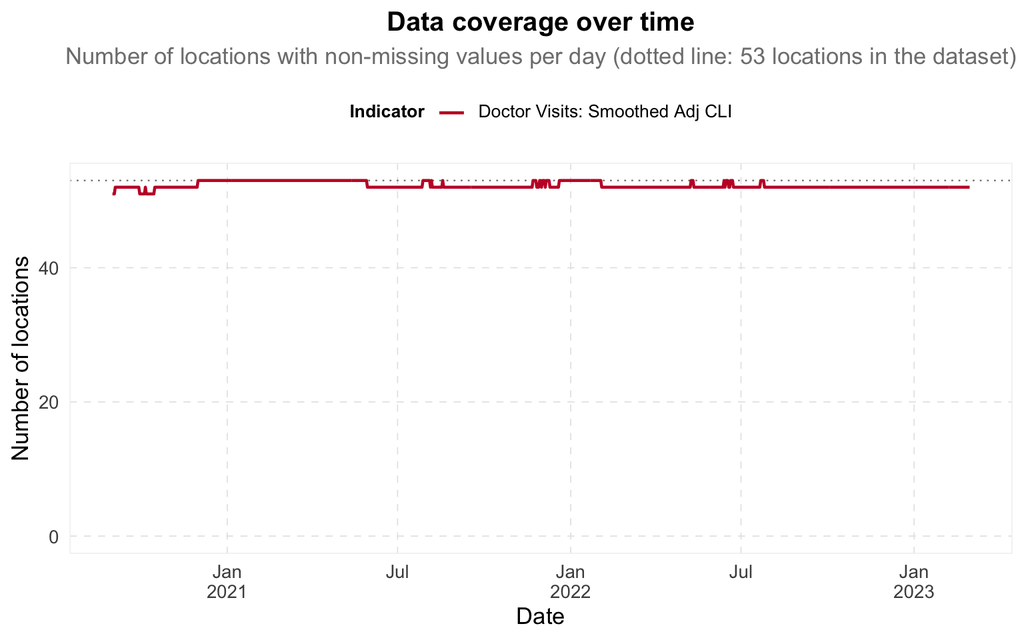

```r
ggplot(coverage, aes(x = time_value, y = n_available,
                     color = indicator, linetype = indicator)) +
    geom_hline(yintercept = n_locations, linetype = 3, linewidth = 0.4, color = "gray50") +
    geom_line(linewidth = 0.8) +
    scale_x_date(breaks = breaks_pretty(), label = label_date_short()) +
    scale_y_continuous(labels = label_comma(), limits = c(0, NA)) +
    labs(
        title = "Data coverage over time",
        subtitle = sprintf("Number of locations with non-missing values per %s (dotted line: %d locations in the dataset)",
                           env_time_type, n_locations),
        x = "Date", y = "Number of locations",
        color = "Indicator", linetype = "Indicator"
    ) +
    {if (length(signals_vec) > 6 || length(params$extra_keys) > 0) facet_wrap(reformulate(c(if (length(signals_vec) > 6) "indicator", params$extra_keys)), ncol = 2, labeller = label_wrap_html(width = 25)) else NULL}
```

#### 2.1.1 Summary Statistics by Location

This table summarizes the available data across all included locations. Locations with no candidate information are not considered.

**Missingness Overview (All Locations):**

- **<5% missing**: 52 locations
- **5-25% missing**: 0 locations
- **25-50% missing**: 0 locations
- **50-99.9% missing**: 1 locations
- **100% missing**: 0 locations

| Location (state) | Periods with Values Reported | Possible Periods with Values | Avg. Value | % Missing |
| --- | --- | --- | --- | --- |
| Puerto Rico Commonwealth | 289 | 912 | 33.21232647750865 | 68.3% |
| U.S. Virgin Islands | 867 | 912 | 4.868610596309112 | 4.9% |
| Alaska | 912 | 912 | 1.043549587719298 | 0.0% |
| Alabama | 912 | 912 | 3.691690532894736 | 0.0% |
| Arkansas | 912 | 912 | 3.543075333333333 | 0.0% |
| Arizona | 912 | 912 | 3.203633766447368 | 0.0% |
| California | 912 | 912 | 5.551641896929824 | 0.0% |
| Colorado | 912 | 912 | 2.746880996710527 | 0.0% |
| Connecticut | 912 | 912 | 3.814654831140349 | 0.0% |
| District of Columbia | 912 | 912 | 4.957224817982455 | 0.0% |

[output cut: 43 more lines]

### 2.2 Time Series Overview

The candidate indicator over time, one location at a time (use the dropdown to switch). Values are shown as published: the line breaks where a period has no value and each marker is one observation, so gaps read as gaps rather than as straight interpolated lines.

```r
all_geos <- sort(unique(df_candidate$geo_value))
sample_geos <- random_sample(all_geos, min(length(all_geos), params$max_locations_plot))

# Bands are drawn when the source reports bounds.
ci_cols <- intersect(c("ci_lower", "ci_upper"), colnames(df_candidate))
if (length(ci_cols) < 2) ci_cols <- NULL

df_sample <- df_candidate %>%
    as_tibble() %>%
    filter(geo_value %in% sample_geos) %>%
    # Fill the grid so missing periods become explicit NAs; plotly then leaves a
    # gap instead of joining across them.
    complete(nesting(!!!rlang::syms(c(signal_key, "time_value"))),
             !!!rlang::syms(params$extra_keys), geo_value) %>%
    add_indicator() %>%
    # Name the dropdown entries; nothing downstream joins on the code.
    mutate(geo_value = geo_to_name(geo_value))

# One trace per indicator and, if present, per level of the first stratifier
# (combined into a single key so both distinctions get their own legend entry).
trace_parts <- c(if (multi_signal) "indicator" else NULL,
                  if (length(params$extra_keys) > 0) params$extra_keys[1] else NULL)
trace_col <- if (length(trace_parts) > 1) {
    df_sample[[".trace"]] <- do.call(paste, c(unname(df_sample[trace_parts]), sep = " / "))
    ".trace"
} else if (length(trace_parts) == 1) trace_parts else NULL

if (!is.null(ci_cols)) {
    cat(sprintf(
        "Shaded bands are the confidence interval reported with each value%s.\n\n",
        if (!is.null(trace_col)) {
            sprintf(", drawn in the colour of their %s and sharing its legend entry, so clicking one in the legend hides its line and its band together",
                    if (length(trace_parts) > 1) paste(trace_parts, collapse = "/") else trace_col)
        } else ""
    ))
}

p <- plot_series_dropdown(df_sample, trace_col = trace_col, ci_cols = ci_cols)
if (!is.null(p) && !is.null(attr(p, "bands_wide")) && attr(p, "bands_wide") > 0) {
    cat(sprintf(
        "An estimate on almost no denominator has an interval about as wide as the indicator itself, which drawn is a full-height column hiding every other series. %s of %s reported values (%s) have an interval wider than the full range of the values, so no band is drawn for them. Those observations still show as a line and a marker, and the y axis follows the values rather than the bands, so a band running off the top is clipped.\n\n",
        label_comma()(attr(p, "bands_wide")), label_comma()(attr(p, "bands_total")),
        label_percent(accuracy = 0.1)(attr(p, "bands_wide") / attr(p, "bands_total"))
    ))
}
# SVG, not toWebGL: WebGL cannot fill a ribbon polygon and would break the
# bands. Only one location shows at a time, so SVG is fast enough.
if (!is.null(p)) p %>% plotly::partial_bundle()
```

[interactive chart not shown]

### 2.3 Quantile Trends

The distribution of the indicator across locations over time. The line is the median, the inner ribbon the 25th-75th percentile range (the middle 50% of locations), the outer ribbon the 5th-95th. Each panel has its own scale.

Ribbon width is geographic variability: narrow means locations agree, wide means they spread.

Quantiles are smoothed with a moving average, which is meant for raw data whose day-of-week effect would otherwise dominate the ribbons. An indicator already smoothed at the source does not need it, and smoothing twice only widens the effective window; set `smooth_quantiles: false` to plot the quantiles as published.

Each quantile covers only the locations that reported in that window, so panels with different location counts (shown in the panel labels) are not comparable. A spike in one panel alone is often composition: a location reporting only the aggregate stratum, on a small denominator, lifts that panel’s upper quantile and no other.

```r
cat("\n")
```

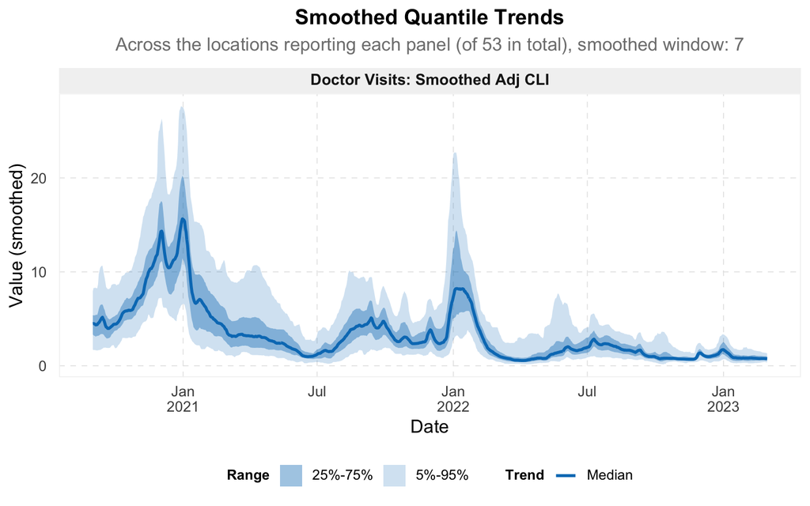

```r
# One row per (key, period); geo_value is constant so epi_slide partitions by
# the keys alone.
df_quantiles_wide <- df_candidate %>%
    group_by(across(all_of(c(strat_keys, "time_value")))) %>%
    summarize(
        vals = list(value),
        geo_value = "all",
        .groups = "drop"
    ) %>%
    as_epi_df(signal_format = "as_is", other_keys = strat_keys)

# Smoothing window, matched to the time type.
window_size <- switch(env_time_type %||% "unknown",
    day   = 7L, # 7-day smoothing
    week  = as.difftime(3, units = "weeks"), # 3-week smoothing
    month = as.difftime(3, units = "months"), # 3-month smoothing
    year  = as.difftime(3, units = "years"), # 3-year smoothing
    Inf # Default to cumulative for unknown types
    # (too sparse for sliding averages)
)

q_tbl <- function(v) {
    tibble(
        `0.05` = quantile(v, 0.05, na.rm = TRUE),
        `0.25` = quantile(v, 0.25, na.rm = TRUE),
        `0.5`  = quantile(v, 0.5, na.rm = TRUE),
        `0.75` = quantile(v, 0.75, na.rm = TRUE),
        `0.95` = quantile(v, 0.95, na.rm = TRUE)
    )
}

df_quantiles_wide <- {
    if (smooth_quantiles) {
        df_quantiles_wide %>%
            group_by(across(all_of(c("geo_value", strat_keys)))) %>%
            epi_slide(~ q_tbl(unlist(.x$vals)), .window_size = window_size) %>%
            ungroup()
    } else {
        # Quantiles of the values published in that period alone.
        bind_cols(df_quantiles_wide, map_dfr(df_quantiles_wide$vals, q_tbl))
    }
} %>%
    as_tibble() %>%
    add_indicator() %>%
    label_strata_coverage(params$extra_keys)

ggplot(df_quantiles_wide, aes(x = time_value)) +
    geom_ribbon(aes(ymin = `0.05`, ymax = `0.95`, fill = "5%-95%"), alpha = 0.2) +
    geom_ribbon(aes(ymin = `0.25`, ymax = `0.75`, fill = "25%-75%"), alpha = 0.4) +
    geom_line(aes(y = `0.5`, color = "Median"), linewidth = 1) +
    facet_wrap(reformulate(c("indicator", params$extra_keys)), ncol = 1, scales = "free_y") +
    scale_x_date(breaks = breaks_pretty(), label = label_date_short()) +
    scale_y_continuous(labels = scales::label_number(scale_cut = scales::cut_si(""))) +
    scale_fill_manual(values = c("5%-95%" = dis_pal_list[2], "25%-75%" = dis_pal_list[2])) +
    scale_color_manual(values = c("Median" = dis_pal_list[2])) +
    labs(
        title = if (smooth_quantiles) "Smoothed Quantile Trends" else "Quantile Trends",
        subtitle = sprintf("Across the locations reporting each panel (of %d in total)%s",
                           n_locations,
                           if (smooth_quantiles) sprintf(", smoothed window: %s", format(window_size)) else ", as published"),
        x = "Date", y = if (smooth_quantiles) "Value (smoothed)" else "Value",
        fill = "Range", color = "Trend"
    ) +
    theme(legend.position = "bottom")
```

#### 2.3.1 Cross-Sectional Geographic Outliers

The quantile plots summarize the body of the distribution and can hide erratic individual locations. This table places each one within it, counting how often the location sits above the 95th percentile or below the 5th for its own period and stratum. Both shares are out of the periods the location reported, not the analysis window, and the count of reported values is shown so a location with three observations is not read as a stable 100%.

How to read it: 5% is where chance alone puts a location, so only distances from 5% carry information. A location above the 95th percentile most of the time is not having a long outbreak, it is sitting at a different level from everyone else. The same holds at the bottom, where a high zero share is the more common symptom. A location in *both* tails is unstable rather than high or low.

**Note**

This compares locations against one another on each period, so it reports relative position only, never whether a value is correct. If the indicator relies on raw counts rather than rates or percentages, the table will mostly find the largest populations, reflecting size rather than outliers. Set `show_geo_outliers: false` to drop the section.

| Location | Periods with Values Reported | % Above 95th | % Below 5th | % Exactly Zero |
| --- | --- | --- | --- | --- |
| Puerto Rico Commonwealth | 289 | 85.81314878892734 | 2.768166089965398 | 1.384083044982699 |
| New Jersey | 912 | 43.75 | 0 | 0 |
| Maryland | 912 | 35.96491228070175 | 0 | 0 |
| New York | 912 | 29.60526315789473 | 0 | 0 |
| U.S. Virgin Islands | 867 | 25.60553633217993 | 7.035755478662054 | 1.384083044982699 |
| California | 912 | 24.89035087719298 | 0 | 0 |
| Michigan | 912 | 15.46052631578947 | 0 | 0 |
| Rhode Island | 912 | 11.62280701754386 | 0 | 0 |
| Minnesota | 912 | 11.29385964912281 | 0 | 0 |
| District of Columbia | 912 | 10.6359649122807 | 0 | 0 |

[output cut: 43 more lines]

### 2.4 Temporal Variability

The coefficient of variation (CV) measures how much the indicator moves over time in each location. A high CV is not evidence of noise on its own: epidemic dynamics, seasonality and genuine level shifts all raise it. Read it as the size of the variation, use the seasonality and revision sections to judge how much of it is real, and treat it comparatively.

The CV uses only reported values, so missing periods neither contribute nor count against it, and it is computed per (location, stratum). Pooling strata would measure the spread between them, since a location’s strata usually sit at different levels.

The CV is undefined for a location with a mean of zero or fewer than two values. Those series cannot appear in the histogram, so the caption counts them and the bars reconcile against the location count.

$$\text{CV}_i = \frac{\text{SD}(X_i)}{|\bar{X}_i|}$$

```r
# One CV per (indicator, stratum, location), over reported values only
noise_stats <- df_candidate %>%
    as_tibble() %>%
    filter(!is.na(value)) %>%
    group_by(across(all_of(c(strat_keys, "geo_value")))) %>%
    summarize(
        n_obs = n(),
        cand_cv = sd(value) / abs(mean(value)),
        .groups = "drop"
    )

n_series <- nrow(noise_stats)
noise_undefined <- noise_stats %>% filter(!is.finite(cand_cv))
noise_stats <- noise_stats %>% filter(is.finite(cand_cv))

# Clip extreme outliers so the histogram stays readable
cv_upper <- quantile(noise_stats$cand_cv, 0.99, na.rm = TRUE)
noise_stats_plot <- noise_stats %>%
    filter(cand_cv <= cv_upper) %>%
    add_indicator() %>%
    label_strata_coverage(params$extra_keys)

n_excluded <- nrow(noise_stats) - nrow(noise_stats_plot)

# Summary Table — one row per (indicator, stratum)
noise_summary <- noise_stats %>%
    group_by(across(all_of(strat_keys))) %>%
    summarize(median_cv = median(cand_cv), n_locs = n_distinct(geo_value), .groups = "drop") %>%
    mutate(across(all_of(params$extra_keys), order_strata)) %>%
    add_indicator() %>%
    arrange(across(all_of(params$extra_keys))) %>%
    select(
        any_of(if (has_signal && multi_signal) "indicator" else character(0)),
        all_of(params$extra_keys), n_locs, median_cv
    )

DT::datatable(noise_summary,
    colnames = c(
        if (has_signal && multi_signal) "Indicator" else NULL,
        str_to_title(str_replace_all(params$extra_keys, "_", " ")),
        "Locations", "Median CV"
    ),
    caption = sprintf(
        "CV summary across locations. %d of %d (location%s) series have a defined CV%s%s.",
        nrow(noise_stats), n_series,
        if (length(params$extra_keys) > 0) " x stratum" else "",
        if (nrow(noise_undefined) > 0) {
            sprintf("; %d dropped as undefined (zero mean or a single reported value)", nrow(noise_undefined))
        } else "",
        if (n_excluded > 0) sprintf("; a further %d above the 99th percentile are excluded from the plot", n_excluded) else ""
    ),
    rownames = FALSE, options = list(scrollX = TRUE, scrollY = "300px", scrollCollapse = TRUE, paging = TRUE, dom = "tp")
) %>% DT::formatRound(columns = ncol(noise_summary), digits = 3)
```

| Locations | Median CV |
| --- | --- |
| 53 | 0.9499702864394725 |

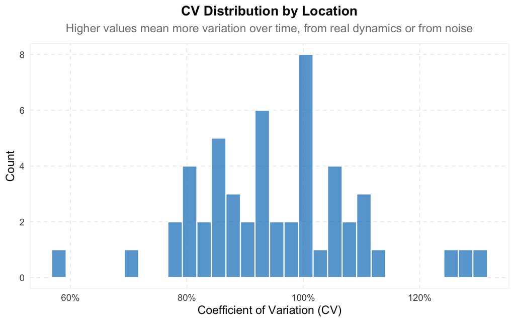

```r
# Histogram (faceted by indicator x stratum)
ggplot(noise_stats_plot, aes(x = cand_cv)) +
    geom_histogram(bins = 30, color = "white", fill = dis_pal_list[2], alpha = 0.7) +
    scale_x_continuous(labels = label_percent()) +
    {if (multi_signal || length(params$extra_keys) > 0) facet_wrap(reformulate(c(if (multi_signal) "indicator", params$extra_keys)), scales = "free", labeller = label_wrap_html(width = 25)) else NULL} +
    labs(
        title = "CV Distribution by Location",
        subtitle = "Higher values mean more variation over time, from real dynamics or from noise",
        x = "Coefficient of Variation (CV)", y = "Count"
    ) +
    theme(legend.position = "none")
```

### 2.5 Candidate Versioning

Versioning is not the focus here. This section answers only whether the indicator revises at all and roughly how much. Relative revisions are scaled to the indicator’s own magnitude: 0.1 means the observation shifted by 10% of its own size, and values near 1 mean revisions as large as the indicator itself.

**Tip**

For revision lags by location, convergence over time, and how much of the latest value is knowable at each lag, use `revision_analysis/revision_analysis.qmd`.

> The `revision_summary` is under revision and may produce misleading results in certain edge cases. Use the summary statistics below with caution while development is ongoing.

Revision analysis is performed on a sample of 53 out of 53 locations, with versions from 2020-07-07 to 2023-05-13, and time from 2020-07-03 to 2023-03-01.

- **Time range**: 2020-07-03 to 2023-03-01
- **Min lag (days to first version)**: Min.: 3, 1st Qu.: 3, Median: 4, Mean: 3.6, 3rd Qu.: 4, Max.: 5
- **Total number of versions**: 881
- **No revisions**: 0%
- **Quick revisions (<= 3 days)**: 0%
- **Few revisions (<= 3)**: 0%
- **Minor relative revisions (< 0.1)**: 3%
- **Major absolute revisions (> 3.966)**: 5%
- **Days until within 20% of latest**: Min.: 3, 1st Qu.: 4, Median: 8, Mean: 13.7, 3rd Qu.: 17, Max.: 73

### 2.6 Indicator sanity checks

These are hard to automate. Things to look for:

- Do the values match what you expected? This catches the most, and only you can make the call: state the range, level and shape you expect from the indicator’s definition before reading the plots, then compare.
- If it’s a percentage or percentile, is it between 0 and 100?
- If it’s a count, does it scale with population? One that doesn’t points at a coverage or denominator problem. A rate or percentage is already normalized, so its level should instead be comparable across locations of very different sizes, and one far off the rest is worth investigating. The relevant denominator is usually not the resident population but the part the source observes.
- Are the values plausible? A percentage approaching 100 outside a pandemic, for instance.
- For a seasonal disease, are rates highest in winter and lowest in summer?
- Do the coarser geographies aggregate plausibly?

The histogram and table below show the distribution of all values and the range per location, to judge whether that range fits the indicator’s expected scale.

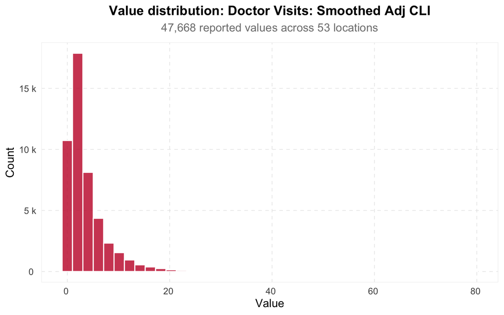

```r
df_candidate_plot <- df_candidate %>% add_indicator()

ggplot(df_candidate_plot, aes(x = value)) +
    geom_histogram(bins = 40, alpha = 0.8, color = "white") +
    scale_x_continuous(labels = label_number(scale_cut = cut_si(""))) +
    scale_y_continuous(labels = label_number(scale_cut = cut_si(""))) +
    {if (multi_signal) facet_wrap(~indicator, scales = "free", labeller = label_wrap_html(width = 25)) else NULL} +
    labs(
        title = if (multi_signal) "Value distribution by indicator"
                else sprintf("Value distribution: %s", signal_labels[signals_vec]),
        subtitle = sprintf(
            "%s reported values across %d locations",
            label_comma()(nrow(df_candidate)), n_locations
        ),
        x = "Value", y = "Count"
    )
```

| Location | N | Min | 5th pct | Median | 95th pct | Max |
| --- | --- | --- | --- | --- | --- | --- |
| Puerto Rico Commonwealth | 289 | 0 | 1.8451798 | 32.401616 | 68.36512459999999 | 79.135443 |
| Minnesota | 912 | 0.568083 | 0.7277097 | 2.369226 | 21.43057644999999 | 40.886239 |
| New York | 912 | 0.941907 | 1.54285325 | 4.345865 | 17.18055264999999 | 33.555443 |
| Maryland | 912 | 0.97384 | 1.3970263 | 5.201892 | 19.20538199999999 | 32.963185 |
| California | 912 | 0.726662 | 1.02744065 | 4.551288 | 14.35295399999999 | 32.63711 |
| District of Columbia | 912 | 0.47701 | 0.72155705 | 3.7098065 | 14.76828794999999 | 28.021529 |
| New Jersey | 912 | 1.295038 | 1.8797899 | 4.6168435 | 18.86992975 | 28.021194 |
| Michigan | 912 | 0.568378 | 1.03345375 | 3.355565 | 15.87665794999999 | 27.195952 |
| Texas | 912 | 0.550819 | 0.7504734500000001 | 2.717111 | 14.05214779999999 | 27.033963 |
| Illinois | 912 | 0.78335 | 1.01045225 | 3.426111 | 16.83881139999999 | 26.871424 |

[output cut: 43 more lines]

The seasonal pattern of the indicator, one panel per epidemiological year (July-June). The line is the monthly median across locations, the inner band the 25th-75th percentile range (the middle 50% of that month’s observations), the outer band the full min-max range.

The year boundary comes from `season_start_month`, which defaults to July so a northern-hemisphere respiratory season falls inside one panel, following the usual influenza convention. Set another month for indicators peaking elsewhere in the year.

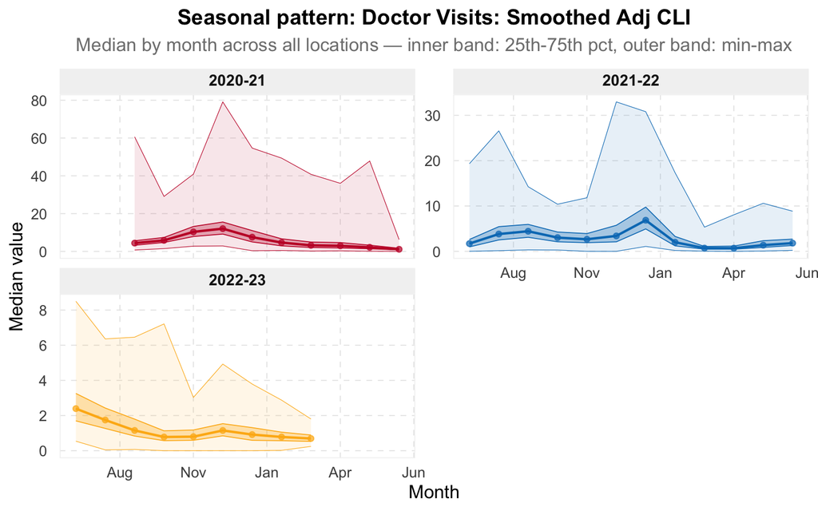

```r
df_seasonal <- df_candidate %>%
    as_tibble() %>%
    add_season() %>%
    group_by(across(all_of(c(strat_keys, "season", "season_month")))) %>%
    summarize(
        median_val = median(value, na.rm = TRUE),
        min_val = min(value, na.rm = TRUE),
        max_val = max(value, na.rm = TRUE),
        p25 = quantile(value, 0.25, na.rm = TRUE),
        p75 = quantile(value, 0.75, na.rm = TRUE),
        .groups = "drop"
    ) %>%
    # Keep only (key x season) combos with >= 3 months of data
    semi_join(
        count(., across(all_of(c(strat_keys, "season")))) %>% filter(n >= 3),
        by = c(strat_keys, "season")
    ) %>%
    add_indicator() %>%
    label_strata_coverage(params$extra_keys)

ggplot(df_seasonal, aes(x = season_month, color = season, fill = season, group = season)) +
    geom_ribbon(aes(ymin = min_val, ymax = max_val), alpha = 0.10, linewidth = 0.2) +
    geom_ribbon(aes(ymin = p25, ymax = p75), alpha = 0.30, linewidth = 0.3) +
    geom_line(aes(y = median_val), linewidth = 0.8) +
    geom_point(aes(y = median_val), size = 1.5) +
    {
        row_vars <- c(if (multi_signal) "indicator", params$extra_keys)
        if (length(row_vars) > 0) {
            facet_grid(as.formula(paste(paste(row_vars, collapse = " + "), "~ season")), scales = "free_y")
        } else {
            facet_wrap(~season, ncol = 2, scales = "free_y")
        }
    } +
    scale_x_continuous(labels = ~ month.abb[((season_start_month - 2L + .x) %% 12L) + 1L]) +
    scale_y_continuous(labels = label_number(scale_cut = cut_si(""))) +
    labs(
        title = if (multi_signal) "Seasonal patterns by indicator"
                else sprintf("Seasonal pattern: %s", signal_labels[signals_vec]),
        subtitle = "Median by month across all locations — inner band: 25th-75th pct, outer band: min-max",
        x = "Month", y = "Median value"
    ) +
    theme(legend.position = "none")
```

No geo-aggregation violations found: all HHS/nation values are within the [min, max] of constituent state values for Doctor Visits: Smoothed Adj CLI.

The table below flags locations whose seasonal peak is at least twice the typical (median) peak across all locations in the same season.

| Season | Location | Location Max | Typical Max | Ratio |
| --- | --- | --- | --- | --- |
| 2020-21 | Puerto Rico Commonwealth | 79.135443 | 18.083767 | 4.376048585452356 |
| 2021-22 | Maryland | 32.963185 | 10.979156 | 3.002342347626721 |
| 2021-22 | District of Columbia | 28.021529 | 10.979156 | 2.552248005220073 |
| 2022-23 | Puerto Rico Commonwealth | 8.501407 | 3.429886 | 2.478626694881404 |
| 2021-22 | Puerto Rico Commonwealth | 26.685531 | 10.979156 | 2.430563059674168 |
| 2021-22 | Florida | 25.498562 | 10.979156 | 2.322451926177203 |
| 2021-22 | U.S. Virgin Islands | 24.853533 | 10.979156 | 2.263701599649372 |
| 2020-21 | Minnesota | 40.886239 | 18.083767 | 2.260935954328542 |
| 2022-23 | Oregon | 7.211654 | 3.429886 | 2.102592914166826 |
| 2021-22 | New Jersey | 22.686818 | 10.979156 | 2.066353552130965 |

[output cut: 1 more lines]